# METABRIC validation on a common gene universe

## Anchored predicted age vs chronological age

```r
panelB_df <- all_df %>%
  dplyr::select(cohort, age_years, pred_anchored) %>%
  dplyr::filter(complete.cases(age_years, pred_anchored))

table(panelB_df$cohort)
```

```
##
##     GTEx TCGA-NAT  TCGA-PT   SCAN-B METABRIC
##      482      112     1117     7744     1980
```

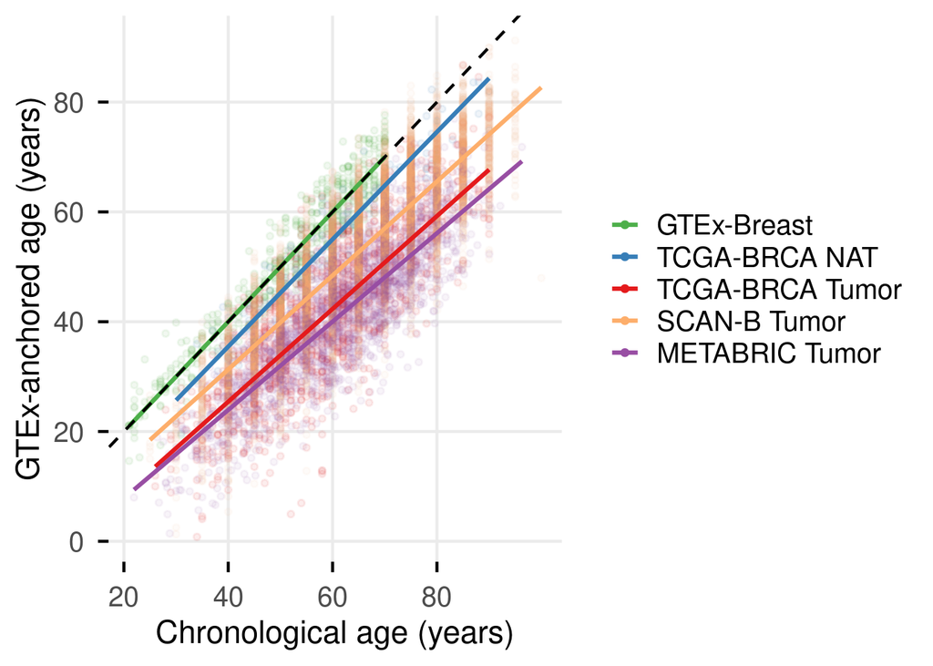

```r
p_panelB <- ggplot(panelB_df, aes(x = age_years, y = pred_anchored, colour = cohort)) +
  geom_point(aes(alpha = cohort), size = 1.2) +
  geom_smooth(method = "lm", se = FALSE, linewidth = 1.1) +
  geom_abline(slope = 1, intercept = 0, linetype = "dashed", colour = "black") +
  scale_colour_manual(values = cohort_cols_full, labels = cohort_labels_full) +
  scale_alpha_manual(
    values = c("GTEx" = 0.08, "TCGA-NAT" = 0.08, "TCGA-PT" = 0.08,
               "SCAN-B" = 0.04, "METABRIC" = 0.06),
    guide  = "none"
  ) +
  scale_x_continuous(breaks = c(0, 20, 40, 60, 80)) +
  scale_y_continuous(breaks = c(0, 20, 40, 60, 80)) +
  labs(x = "Chronological age (years)", y = "GTEx-anchored age (years)") +
  theme_minimal(base_size = 17) +
  theme(
    legend.title      = element_blank(),
    panel.grid.minor  = element_blank(),
    axis.ticks        = element_line(),
    axis.ticks.length = unit(2, "mm"),
    axis.title        = element_text(size = 17),
    axis.text         = element_text(size = 15),
    legend.text       = element_text(size = 15)
  )

p_panelB
```

```r
ggsave(
  filename = file.path(fig_out_dir, "anchored_age_5cohorts.pdf"),
  plot     = p_panelB,
  width    = 220 / 25.4, height = 130 / 25.4, units = "in"
)
```

## Representative ClockSHAP waterfall (TCGA-BRCA; not used in the manuscript)

Single TCGA-BRCA tumor in middle-deviation range with readable top-N |phi| bars. Preserved here as a diagnostic.

```r
pick_pretty_waterfall_sample <- function(cs, top_n = 10,
                                         dev_q = c(0.20, 0.80),
                                         min_bar = 2.5) {
  stopifnot(inherits(cs, "clockshap"))
  phi <- cs$phi
  ids <- rownames(phi)
  if (is.null(ids)) stop("ClockSHAP object has no rownames for phi.", call. = FALSE)

  ok  <- is.finite(cs$deviation) & is.finite(cs$expected) & is.finite(cs$predicted)
  phi <- phi[ok, , drop = FALSE]; dev <- cs$deviation[ok]; ids <- ids[ok]

  lo <- unname(stats::quantile(dev, dev_q[1], na.rm = TRUE))
  hi <- unname(stats::quantile(dev, dev_q[2], na.rm = TRUE))
  keep <- dev >= lo & dev <= hi

  phi2 <- phi[keep, , drop = FALSE]
  ids2 <- ids[keep]
  if (nrow(phi2) == 0) stop("No samples left after dev_q filtering.", call. = FALSE)

  top_abs  <- t(apply(abs(phi2), 1, function(v) sort(v, decreasing = TRUE)[seq_len(top_n)]))
  min_top  <- apply(top_abs, 1, min)
  mean_top <- rowMeans(top_abs)
  cand <- which(min_top >= min_bar)
  if (length(cand) == 0) cand <- seq_len(nrow(phi2))
  ids2[cand[which.max(mean_top[cand])]]
}

sample_id <- pick_pretty_waterfall_sample(cs = cs_pt$cs, top_n = 10,
                                          dev_q = c(0.20, 0.80), min_bar = 2.5)
cat("Representative BRCA sample:", sample_id, "\n")
```

```
## Representative BRCA sample: 1a258ee7-6bbc-4fa0-bc26-9c5243d7b04b
```

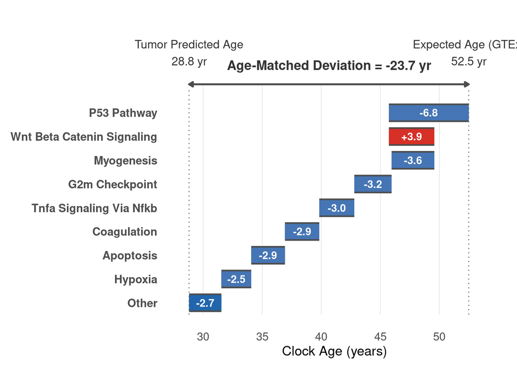

```r
p_waterfall <- ClockSHAP::plot_clockshap_waterfall(
  x                   = cs_pt$cs,
  sample              = sample_id,
  top_n               = 8,
  show_age_labels     = TRUE,
  show_delta_label    = TRUE,
  show_effect_labels  = TRUE,
  x_axis_title        = "Clock Age (years)",
  y_axis_title        = NULL,
  deviation_label     = "Age-Matched Deviation = {value} yr",
  expected_age_label  = "Expected Age (GTEx)\n{value} yr",
  predicted_age_label = "Tumor Predicted Age\n{value} yr",
  effect_label        = "{value}"
) +
  theme(
    axis.title.x = element_text(size = 13),
    axis.text.x  = element_text(size = 11),
    axis.text.y  = element_text(size = 11),
    plot.margin  = margin(t = 20, r = 10, b = 10, l = 10)
  )

p_waterfall
```

```r
ggsave(
  filename = file.path(fig_out_dir, "ClockSHAP_waterfall_representative_TCGABRCA.pdf"),
  plot     = p_waterfall,
  width    = 180 / 25.4, height = 130 / 25.4, units = "in"
)
```

## ClockSHAP heatmaps (TCGA-BRCA + SCAN-B + METABRIC; not used in the manuscript)

Three heatmaps with shared color scales and annotation palette. TCGA-BRCA holds row labels and legends; SCAN-B and METABRIC inherit BRCA’s hierarchical row order.

```r
build_phi_mat <- function(cs_obj) {
  phi <- cs_obj$cs$phi
  dev <- cs_obj$cs$deviation
  ids <- rownames(phi)
  ok <- is.finite(dev)
  phi <- phi[ok, , drop = FALSE]; dev <- dev[ok]; ids <- ids[ok]
  ord <- order(dev, decreasing = FALSE)
  phi <- phi[ord, , drop = FALSE]; dev <- dev[ord]; ids <- ids[ord]
  mat <- t(phi); colnames(mat) <- ids
  mat <- mat[rowSums(abs(mat), na.rm = TRUE) != 0, , drop = FALSE]
  rownames(mat)[rownames(mat) == "Reactive Oxygen Species Pathway"] <- "ROS Pathway"
  list(mat = mat, dev = dev, ids = ids)
}

brca_b  <- build_phi_mat(cs_pt)
scanb_b <- build_phi_mat(cs_scanb)
metab_b <- build_phi_mat(cs_metab)

# Cluster on BRCA — others inherit the row ordering
hc_brca        <- hclust(dist(brca_b$mat))
brca_row_order <- rownames(brca_b$mat)[hc_brca$order]
scanb_b$mat <- scanb_b$mat[intersect(brca_row_order, rownames(scanb_b$mat)), , drop = FALSE]
metab_b$mat <- metab_b$mat[intersect(brca_row_order, rownames(metab_b$mat)), , drop = FALSE]

# Shared color scales
all_dev <- c(brca_b$dev, scanb_b$dev, metab_b$dev)
dev_col_fun <- circlize::colorRamp2(
  c(min(all_dev, na.rm = TRUE), 0, max(all_dev, na.rm = TRUE)),
  c("darkblue", "white", "darkred")
)
phi_lim <- max(as.numeric(stats::quantile(
  c(abs(brca_b$mat), abs(scanb_b$mat), abs(metab_b$mat)),
  probs = 0.99, na.rm = TRUE
)), 1e-6)
phi_col_fun <- circlize::colorRamp2(
  c(-phi_lim, 0, phi_lim),
  c("steelblue", "white", "firebrick")
)

# Shared annotation palettes
pam_cols_shared <- c(
  Basal="#d73027", Her2="#fc8d59", LumA="#4575b4", LumB="#91bfdb",
  `Normal-Like`="#cccccc", Unclassified="grey70"
)
tp53_cols_shared <- c(WT = "grey85", Mut = "black", Unknown = "white")
pam_levels_full  <- names(pam_cols_shared)
tp53_levels_full <- names(tp53_cols_shared)

clean_pam <- function(x) {
  x[is.na(x) | x == "" | x == "NC"] <- "Unclassified"
  factor(dplyr::recode(x, "Normal" = "Normal-Like"), levels = pam_levels_full)
}
clean_tp53 <- function(x) {
  x[is.na(x) | x == ""] <- "Unknown"
  factor(x, levels = tp53_levels_full)
}

pam_brca_ann   <- clean_pam (as.character(metadata[brca_b$ids, "Subtype_Selected"]))
tp53_brca_ann  <- clean_tp53(as.character(metadata[brca_b$ids, "TP53"]))
pam_scanb_ann  <- clean_pam (as.character(SummarizedExperiment::colData(scanb_tumor)[scanb_b$ids, "SSP.PAM50"]))
tp53_scanb_ann <- clean_tp53(as.character(SummarizedExperiment::colData(scanb_tumor)[scanb_b$ids, "TP53"]))
pam_metab_ann  <- clean_pam (as.character(SummarizedExperiment::colData(metabric_se)[metab_b$ids, "Pam50_SUBTYPE"]))
tp53_metab_ann <- clean_tp53(as.character(SummarizedExperiment::colData(metabric_se)[metab_b$ids, "TP53"]))
```

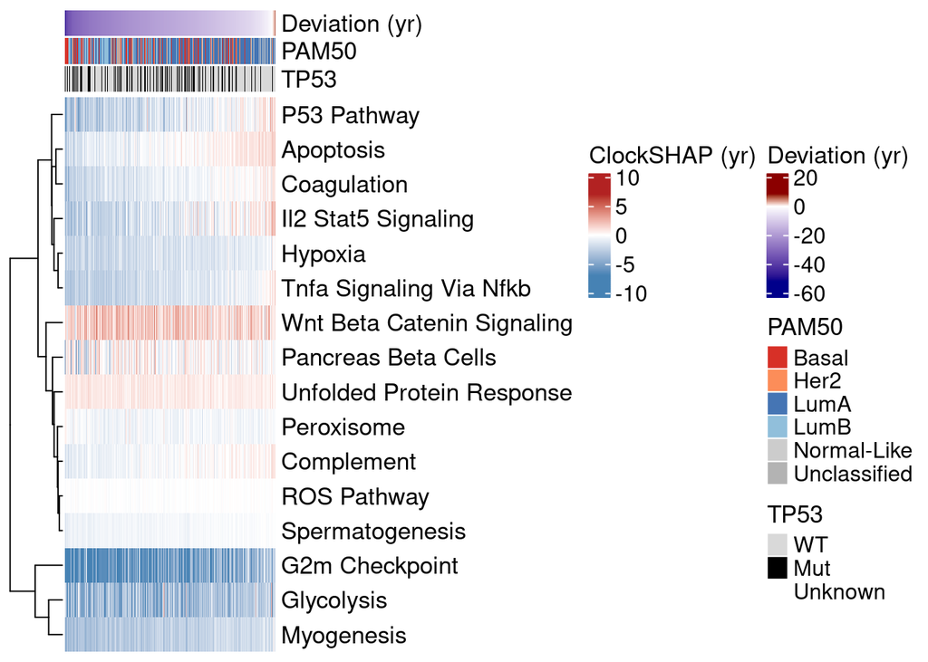

```r
ha_brca <- ComplexHeatmap::HeatmapAnnotation(
  Deviation = brca_b$dev,
  PAM50     = pam_brca_ann,
  TP53      = tp53_brca_ann,
  col = list(Deviation = dev_col_fun, PAM50 = pam_cols_shared, TP53 = tp53_cols_shared),
  annotation_label = list(Deviation = "Deviation (yr)", PAM50 = "PAM50", TP53 = "TP53"),
  annotation_height  = unit(c(3, 3, 3), "mm"),
  annotation_name_gp = gpar(fontsize = 13),
  annotation_legend_param = list(
    Deviation = list(title_gp = gpar(fontsize = 13), labels_gp = gpar(fontsize = 12)),
    PAM50     = list(title_gp = gpar(fontsize = 13), labels_gp = gpar(fontsize = 12),
                     at = pam_levels_full,  labels = pam_levels_full),
    TP53      = list(title_gp = gpar(fontsize = 13), labels_gp = gpar(fontsize = 12),
                     at = tp53_levels_full, labels = tp53_levels_full)
  )
)

ht_panelC_brca <- ComplexHeatmap::Heatmap(
  brca_b$mat,
  name              = "ClockSHAP (yr)",
  col               = phi_col_fun,
  top_annotation    = ha_brca,
  show_row_names    = TRUE,
  row_names_gp      = gpar(fontsize = 13),
  show_column_names = FALSE,
  cluster_rows      = hc_brca,
  cluster_columns   = FALSE,
  show_heatmap_legend  = TRUE,
  heatmap_legend_param = list(title_gp = gpar(fontsize = 13), labels_gp = gpar(fontsize = 12))
)

ht_panelC_brca
```

```r
out_file <- file.path(fig_out_dir, "BRCA_ClockSHAP_heatmap.pdf")
grDevices::pdf(out_file, width = 190 / 25.4, height = 160 / 25.4)
ComplexHeatmap::draw(ht_panelC_brca,
                     heatmap_legend_side = "right",
                     annotation_legend_side = "right",
                     merge_legends = TRUE)
grDevices::dev.off()
```

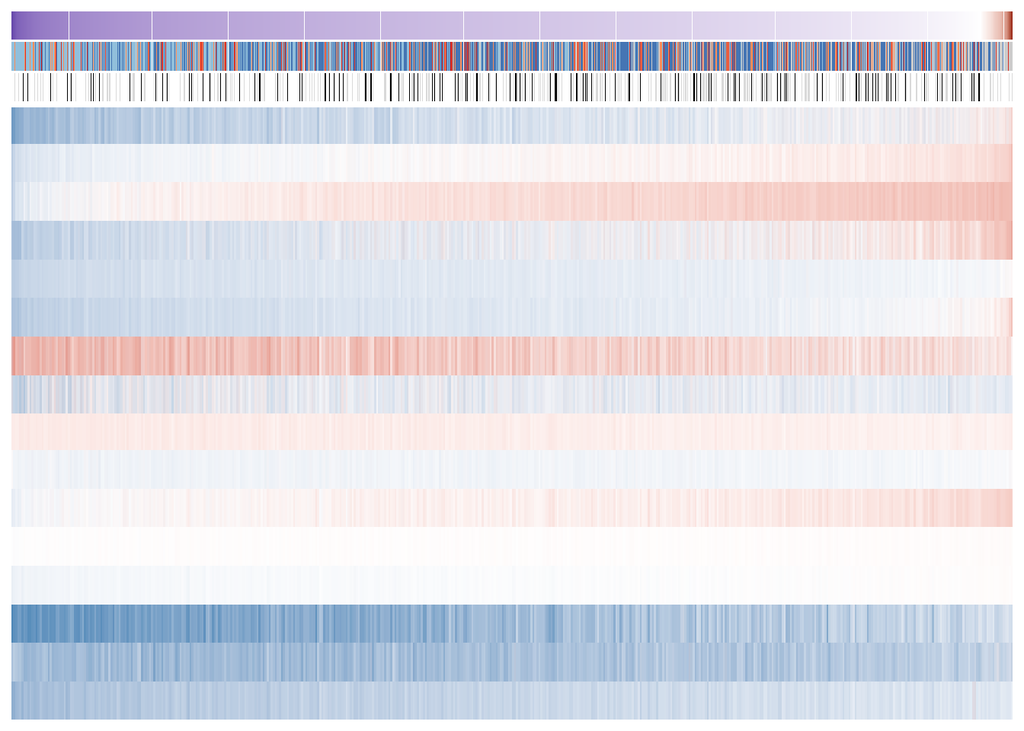

```r
ha_scanb <- ComplexHeatmap::HeatmapAnnotation(
  Deviation = scanb_b$dev,
  PAM50     = pam_scanb_ann,
  TP53      = tp53_scanb_ann,
  col = list(Deviation = dev_col_fun, PAM50 = pam_cols_shared, TP53 = tp53_cols_shared),
  annotation_height = unit(c(3, 3, 3), "mm"),
  show_annotation_name = FALSE,
  show_legend = c(Deviation = FALSE, PAM50 = FALSE, TP53 = FALSE)
)

ht_panelC_scanb <- ComplexHeatmap::Heatmap(
  scanb_b$mat, name = "ClockSHAP (yr)", col = phi_col_fun,
  top_annotation = ha_scanb,
  show_row_names = FALSE, show_column_names = FALSE,
  cluster_rows = FALSE, cluster_columns = FALSE,
  show_heatmap_legend = FALSE
)

ht_panelC_scanb
```

```r
out_file <- file.path(fig_out_dir, "SCANB_ClockSHAP_heatmap.pdf")
grDevices::pdf(out_file, width = 110 / 25.4, height = 160 / 25.4)
ComplexHeatmap::draw(ht_panelC_scanb)
grDevices::dev.off()
```

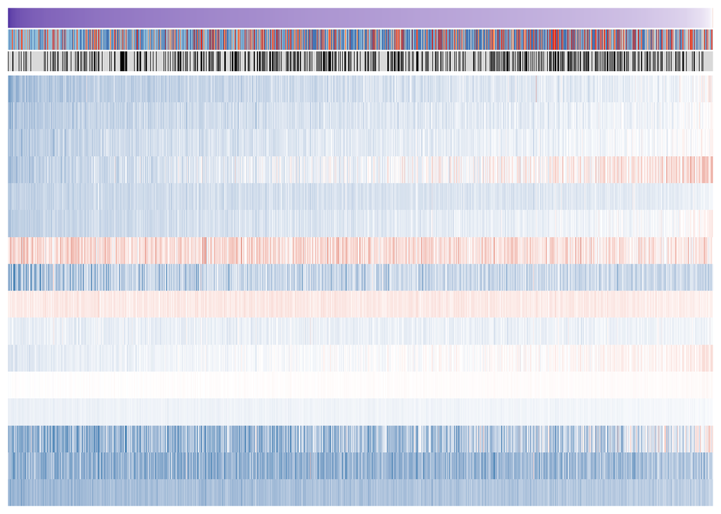

```r
ha_metab <- ComplexHeatmap::HeatmapAnnotation(
  Deviation = metab_b$dev,
  PAM50     = pam_metab_ann,
  TP53      = tp53_metab_ann,
  col = list(Deviation = dev_col_fun, PAM50 = pam_cols_shared, TP53 = tp53_cols_shared),
  annotation_height = unit(c(3, 3, 3), "mm"),
  show_annotation_name = FALSE,
  show_legend = c(Deviation = FALSE, PAM50 = FALSE, TP53 = FALSE)
)

ht_panelC_metab <- ComplexHeatmap::Heatmap(
  metab_b$mat, name = "ClockSHAP (yr)", col = phi_col_fun,
  top_annotation = ha_metab,
  show_row_names = FALSE, show_column_names = FALSE,
  cluster_rows = FALSE, cluster_columns = FALSE,
  show_heatmap_legend = FALSE
)

ht_panelC_metab
```

```r
out_file <- file.path(fig_out_dir, "METABRIC_ClockSHAP_heatmap.pdf")
grDevices::pdf(out_file, width = 110 / 25.4, height = 160 / 25.4)
ComplexHeatmap::draw(ht_panelC_metab)
grDevices::dev.off()
```

## PAM50 deviation across cohorts

```r
ids_brca_d <- rownames(cs_pt$cs$phi)
ids_scanb_d <- rownames(cs_scanb$cs$phi)
ids_metab_d <- rownames(cs_metab$cs$phi)
ids_nat_d   <- rownames(cs_nt$cs$phi)
scanb_cd    <- as.data.frame(SummarizedExperiment::colData(scanb_tumor))
metab_cd    <- as.data.frame(SummarizedExperiment::colData(metabric_se))

clean_pam_str <- function(x) {
  x <- as.character(x); x[is.na(x) | x == "" | x == "NC"] <- NA_character_
  dplyr::recode(x, "Normal" = "Normal-Like")
}

pam50_levels_D <- c("Adjacent Normal", "Normal-Like", "LumA", "LumB", "Her2", "Basal")

panelD_df <- bind_rows(
  tibble(cohort = "TCGA-BRCA", group = "Adjacent Normal",
         deviation = as.numeric(cs_nt$cs$deviation)),
  tibble(cohort = "TCGA-BRCA", group = clean_pam_str(metadata[ids_brca_d, "Subtype_Selected"]),
         deviation = as.numeric(cs_pt$cs$deviation)),
  tibble(cohort = "SCAN-B",    group = clean_pam_str(scanb_cd[ids_scanb_d, "SSP.PAM50"]),
         deviation = as.numeric(cs_scanb$cs$deviation)),
  tibble(cohort = "METABRIC",  group = clean_pam_str(metab_cd[ids_metab_d, "Pam50_SUBTYPE"]),
         deviation = as.numeric(cs_metab$cs$deviation))
) %>%
  filter(group %in% pam50_levels_D, is.finite(deviation)) %>%
  mutate(
    cohort = factor(cohort, levels = c("TCGA-BRCA", "SCAN-B", "METABRIC")),
    group  = factor(group,  levels = pam50_levels_D)
  )

panelD_df %>% dplyr::count(cohort, group) %>% arrange(cohort, group)
```

```
## # A tibble: 16 × 3
##    cohort    group               n
##    <fct>     <fct>           <int>
##  1 TCGA-BRCA Adjacent Normal   112
##  2 TCGA-BRCA Normal-Like        40
##  3 TCGA-BRCA LumA              573
##  4 TCGA-BRCA LumB              217
##  5 TCGA-BRCA Her2               81
##  6 TCGA-BRCA Basal             206
##  7 SCAN-B    Normal-Like      1023
##  8 SCAN-B    LumA             3254
##  9 SCAN-B    LumB             1903
## 10 SCAN-B    Her2              885
## 11 SCAN-B    Basal             679
## 12 METABRIC  Normal-Like       199
## 13 METABRIC  LumA              718
## 14 METABRIC  LumB              488
## 15 METABRIC  Her2              240
## 16 METABRIC  Basal             329
```

```r
fmt_p <- function(p) {
  if (!is.finite(p)) return("p = NA")
  if (p < 2.2e-16) return("p < 2.2e-16")
  paste0("p = ", formatC(p, format = "e", digits = 2))
}

panelD_pvals <- panelD_df %>%
  group_by(cohort) %>%
  group_modify(~ {
    d <- .x %>% filter(group != "Adjacent Normal") %>% mutate(group = droplevels(group))
    if (length(unique(d$group)) < 2) return(tibble(p_value = NA_real_))
    tibble(p_value = suppressWarnings(kruskal.test(deviation ~ group, data = d)$p.value))
  }) %>%
  ungroup() %>%
  rowwise() %>%
  mutate(p_label = paste0("Kruskal-Wallis ", fmt_p(p_value))) %>%
  ungroup()

panelD_pvals
```

```
## # A tibble: 3 × 3
##   cohort     p_value p_label
##   <fct>        <dbl> <chr>
## 1 TCGA-BRCA 1.48e-57 Kruskal-Wallis p < 2.2e-16
## 2 SCAN-B    0        Kruskal-Wallis p < 2.2e-16
## 3 METABRIC  2.42e-89 Kruskal-Wallis p < 2.2e-16
```

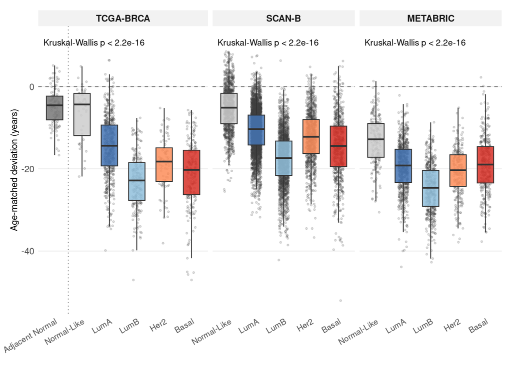

```r
pam50_pal_D <- c(
  "Adjacent Normal" = "#777777",
  "Normal-Like"     = "#cccccc",
  "LumA"            = "#4575b4",
  "LumB"            = "#91bfdb",
  "Her2"            = "#fc8d59",
  "Basal"           = "#d73027"
)

# NAT separator on TCGA-BRCA only
nat_sep_df <- tibble(
  cohort = factor("TCGA-BRCA", levels = c("TCGA-BRCA", "SCAN-B", "METABRIC")),
  x      = 1.5
)

# Position p-value labels at top of shared y
y_max <- max(panelD_df$deviation, na.rm = TRUE)
y_min <- min(panelD_df$deviation, na.rm = TRUE)
y_label_pos <- y_max + 0.05 * (y_max - y_min)

panelD_pvals <- panelD_pvals %>%
  mutate(
    deviation = y_label_pos,
    group     = factor("Normal-Like", levels = pam50_levels_D)
  )

p_panelD <- ggplot(panelD_df, aes(x = group, y = deviation, fill = group)) +
  geom_hline(yintercept = 0, linetype = "dashed", colour = "grey50") +
  geom_vline(data = nat_sep_df, aes(xintercept = x),
             linetype = "dotted", colour = "grey50", inherit.aes = FALSE) +
  geom_jitter(width = 0.18, alpha = 0.18, size = 0.7, colour = "grey25") +
  geom_boxplot(width = 0.6, outlier.shape = NA, alpha = 0.85) +
  scale_fill_manual(values = pam50_pal_D, guide = "none") +
  facet_grid(cols = vars(cohort), scales = "free_x", space = "free_x") +
  geom_text(data = panelD_pvals,
            aes(x = -Inf, y = deviation, label = p_label),
            hjust = -0.05, vjust = 1, size = 3, inherit.aes = FALSE) +
  labs(x = NULL, y = "Age-matched deviation (years)") +
  theme_minimal(base_size = 9) +
   theme(
    panel.grid.minor   = element_blank(),
    panel.grid.major.x = element_blank(),
    strip.text         = element_text(size = 9, face = "bold"),
    strip.background   = element_rect(fill = "grey95", colour = NA),
    axis.title.y       = element_text(size = 9),
    axis.text.x        = element_text(size = 8, angle = 30, hjust = 1),
    axis.text.y        = element_text(size = 9),
    plot.margin        = margin(10, 10, 10, 10)
  )

p_panelD
```

```r
ggsave(
  filename = file.path(fig_out_dir, "PAM50_deviation.pdf"),
  plot     = p_panelD,
  width    = 7.5, height = 2.5, units = "in"
)
```

## Pathway × PAM50 (3 cohorts)

```r
poi_pathways <- c(
  "G2m Checkpoint",
  "Glycolysis",
  "Myogenesis",
  "P53 Pathway",
  "Wnt Beta Catenin Signaling",
  "Unfolded Protein Response"
)

pam50_order <- c("Adjacent Normal", "Normal-Like", "LumA", "LumB", "Her2", "Basal")

build_phi_long <- function(cs_obj, pam_vec, age_vec, cohort_label, poi) {
  phi <- cs_obj$cs$phi
  ids <- rownames(phi)
  poi_avail <- intersect(colnames(phi), poi)
  pam <- as.character(pam_vec[ids])
  pam[is.na(pam) | pam == "" | pam == "NC"] <- "Unclassified"
  pam <- dplyr::recode(pam, "Normal" = "Normal-Like")
  as.data.frame(phi[, poi_avail, drop = FALSE]) %>%
    tibble::rownames_to_column("sample_id") %>%
    tidyr::pivot_longer(-sample_id, names_to = "pathway", values_to = "phi") %>%
    dplyr::mutate(
      PAM50     = pam[match(sample_id, ids)],
      age_years = as.numeric(age_vec[sample_id]),
      cohort    = cohort_label
    )
}

pam_pt    <- setNames(as.character(metadata$Subtype_Selected),       rownames(metadata))
pam_scanb <- setNames(as.character(colData(scanb_tumor)$SSP.PAM50),  colnames(scanb_tumor))
pam_metab <- setNames(as.character(colData(metabric_se)$Pam50_SUBTYPE), colnames(metabric_se))

phi_long_c <- bind_rows(
  build_phi_long(cs_pt,    pam_pt,    age_pt_full,    "TCGA-BRCA", poi_pathways),
  build_phi_long(cs_scanb, pam_scanb, age_scanb_full, "SCAN-B",    poi_pathways),
  build_phi_long(cs_metab, pam_metab, age_metab_full, "METABRIC",  poi_pathways)
) %>%
  filter(PAM50 %in% pam50_order)

# NAT as Adjacent Normal
nat_long <- as.data.frame(cs_nt$cs$phi[, intersect(colnames(cs_nt$cs$phi), poi_pathways), drop = FALSE]) %>%
  tibble::rownames_to_column("sample_id") %>%
  tidyr::pivot_longer(-sample_id, names_to = "pathway", values_to = "phi") %>%
  mutate(
    PAM50     = "Adjacent Normal",
    age_years = as.numeric(age_nt_full[sample_id]),
    cohort    = "TCGA-BRCA"
  )

phi_long_c <- bind_rows(phi_long_c, nat_long) %>%
  mutate(
    pathway = factor(pathway, levels = poi_pathways),
    PAM50   = factor(PAM50,   levels = pam50_order),
    cohort  = factor(cohort,  levels = c("TCGA-BRCA", "SCAN-B", "METABRIC"))
  )

phi_subtype_means <- phi_long_c %>%
  group_by(cohort, pathway, PAM50) %>%
  summarise(n = n(),
            mean_phi = mean(phi, na.rm = TRUE),
            sd_phi   = sd(phi,   na.rm = TRUE),
            se_phi   = sd_phi / sqrt(n),
            .groups  = "drop")

knitr::kable(phi_subtype_means, digits = 3,
             caption = "Per-cohort, per-pathway, per-subtype mean φ, as plotted.")
```

Per-cohort, per-pathway, per-subtype mean φ, as plotted.

| cohort | pathway | PAM50 | n | mean_phi | sd_phi | se_phi |
| --- | --- | --- | --- | --- | --- | --- |
| TCGA-BRCA | G2m Checkpoint | Adjacent Normal | 112 | -1.063 | 1.201 | 0.113 |
| TCGA-BRCA | G2m Checkpoint | Normal-Like | 40 | -3.889 | 1.957 | 0.309 |
| TCGA-BRCA | G2m Checkpoint | LumA | 573 | -4.099 | 1.729 | 0.072 |
| TCGA-BRCA | G2m Checkpoint | LumB | 217 | -7.568 | 1.653 | 0.112 |
| TCGA-BRCA | G2m Checkpoint | Her2 | 81 | -7.456 | 1.642 | 0.182 |
| TCGA-BRCA | G2m Checkpoint | Basal | 206 | -9.014 | 1.826 | 0.127 |
| TCGA-BRCA | Glycolysis | Adjacent Normal | 112 | -1.593 | 1.121 | 0.106 |
| TCGA-BRCA | Glycolysis | Normal-Like | 40 | -2.914 | 1.564 | 0.247 |
| TCGA-BRCA | Glycolysis | LumA | 573 | -2.876 | 1.396 | 0.058 |
| TCGA-BRCA | Glycolysis | LumB | 217 | -3.692 | 1.457 | 0.099 |
| TCGA-BRCA | Glycolysis | Her2 | 81 | -5.079 | 1.614 | 0.179 |
| TCGA-BRCA | Glycolysis | Basal | 206 | -4.526 | 1.796 | 0.125 |
| TCGA-BRCA | Myogenesis | Adjacent Normal | 112 | -0.709 | 0.924 | 0.087 |
| TCGA-BRCA | Myogenesis | Normal-Like | 40 | -1.591 | 0.571 | 0.090 |
| TCGA-BRCA | Myogenesis | LumA | 573 | -2.353 | 0.769 | 0.032 |
| TCGA-BRCA | Myogenesis | LumB | 217 | -3.098 | 0.663 | 0.045 |
| TCGA-BRCA | Myogenesis | Her2 | 81 | -2.808 | 0.631 | 0.070 |
| TCGA-BRCA | Myogenesis | Basal | 206 | -2.679 | 0.870 | 0.061 |
| TCGA-BRCA | P53 Pathway | Adjacent Normal | 112 | 0.152 | 1.541 | 0.146 |
| TCGA-BRCA | P53 Pathway | Normal-Like | 40 | 0.784 | 1.259 | 0.199 |
| TCGA-BRCA | P53 Pathway | LumA | 573 | -1.117 | 1.540 | 0.064 |
| TCGA-BRCA | P53 Pathway | LumB | 217 | -2.266 | 1.271 | 0.086 |
| TCGA-BRCA | P53 Pathway | Her2 | 81 | -1.221 | 1.246 | 0.138 |
| TCGA-BRCA | P53 Pathway | Basal | 206 | -1.493 | 1.871 | 0.130 |
| TCGA-BRCA | Wnt Beta Catenin Signaling | Adjacent Normal | 112 | 0.315 | 0.906 | 0.086 |
| TCGA-BRCA | Wnt Beta Catenin Signaling | Normal-Like | 40 | 0.305 | 1.160 | 0.183 |
| TCGA-BRCA | Wnt Beta Catenin Signaling | LumA | 573 | 1.728 | 0.961 | 0.040 |
| TCGA-BRCA | Wnt Beta Catenin Signaling | LumB | 217 | 2.259 | 0.842 | 0.057 |
| TCGA-BRCA | Wnt Beta Catenin Signaling | Her2 | 81 | 2.336 | 0.987 | 0.110 |
| TCGA-BRCA | Wnt Beta Catenin Signaling | Basal | 206 | 0.320 | 1.047 | 0.073 |

[output cut: 66 more lines]

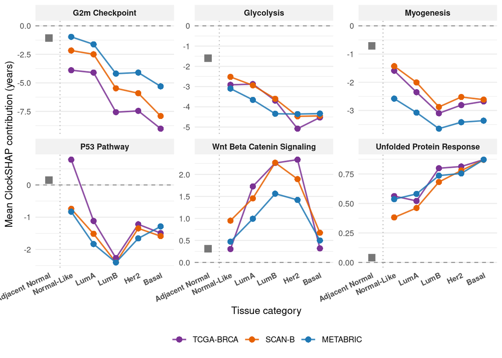

```r
cohort_cols_traj <- c(
  "TCGA-BRCA" = "#7b3294",
  "SCAN-B"    = "#e66101",
  "METABRIC"  = "#1f78b4"
)

p_panelG <- ggplot(phi_subtype_means, aes(x = PAM50, y = mean_phi, group = cohort)) +
  geom_hline(yintercept = 0, linetype = "dashed", colour = "grey55") +
  geom_vline(xintercept = 1.5, linetype = "dotted", colour = "grey70") +
  geom_line(data = phi_subtype_means %>% filter(PAM50 != "Adjacent Normal"),
            aes(colour = cohort), linewidth = 0.7, alpha = 0.85) +
  geom_point(data = phi_subtype_means %>% filter(PAM50 != "Adjacent Normal"),
             aes(colour = cohort), shape = 16, size = 2.6) +
  geom_point(data = phi_subtype_means %>% filter(PAM50 == "Adjacent Normal"),
             shape = 15, size = 3.2, colour = "#777777") +
  scale_x_discrete(limits = pam50_order, drop = FALSE) +
  scale_colour_manual(values = cohort_cols_traj, name = NULL) +
  facet_wrap(~ pathway, scales = "free_y", ncol = 3) +
  labs(x = "Tissue category", y = "Mean ClockSHAP contribution (years)") +
  theme_minimal(base_size = 10) +
  theme(
    strip.text         = element_text(face = "bold"),
    strip.background   = element_rect(fill = "grey95", colour = NA),
    panel.grid.major.x = element_blank(),
    axis.text.x        = element_text(face = "bold", size = 7.5, angle = 25, hjust = 1),
    legend.position    = "bottom"
  )

p_panelG
```

```r
ggsave(
  filename = file.path(fig_out_dir, "pathway_phi_by_pam50_3cohorts.pdf"),
  plot     = p_panelG,
  width    = 7.5, height = 4, units = "in"
)
```

# 11. Overall survival across TCGA-BRCA + SCAN-B + METABRIC

Stacked OS analysis. Three cohorts share `Surv(time, event) ~ age + deviation` Cox models and deviation-tertile KM curves administratively censored at SCAN-B’s natural max follow-up. Time normalized to days across all three cohorts (METABRIC `OS_MONTHS` × 30.4375).

## 11.1 — Load TCGA-BRCA clinical + helpers

```r
stopifnot(file.exists(params$clinical_csv))
clinical <- utils::read.csv(
  params$clinical_csv,
  na.strings        = c("NA", "", "#N/A"),
  stringsAsFactors  = FALSE,
  check.names       = TRUE
)

get_patient12 <- function(x) substr(as.character(x), 1, 12)

# Canonical PAM50 ordering for survival (no NAT — tumors only)
pam50_surv <- c("Normal-Like", "LumA", "LumB", "Her2", "Basal", "Unclassified")

harmonize_pam50 <- function(x) {
  x <- as.character(x)
  x[is.na(x) | x == "" | x == "NC"] <- "Unclassified"
  x <- dplyr::recode(x, "Normal" = "Normal-Like")
  factor(x, levels = pam50_surv)
}

# Survival helper — same Cox extractor as the survival figure script
cox_term <- function(df, formula_str, term_name) {
  fit <- survival::coxph(stats::as.formula(formula_str), data = df)
  co  <- summary(fit)$coefficients
  if (!term_name %in% rownames(co)) return(NULL)
  tibble::tibble(
    HR      = exp(co[term_name, "coef"]),
    CI_low  = exp(co[term_name, "coef"] - 1.96 * co[term_name, "se(coef)"]),
    CI_high = exp(co[term_name, "coef"] + 1.96 * co[term_name, "se(coef)"]),
    p_value = co[term_name, "Pr(>|z|)"]
  )
}
```

## 11.2 — Assemble per-cohort survival data frames

```r
# TCGA-BRCA: deviation/age from cs_pt, OS from TCGA-IntegratedClinical
ids_brca_s <- rownames(cs_pt$cs$phi)
tum_brca <- tibble::tibble(
  sample_id = ids_brca_s,
  age_years = cs_pt$cs$age,
  Deviation = cs_pt$cs$deviation,
  PAM50     = harmonize_pam50(metadata[ids_brca_s, "Subtype_Selected"])
) %>%
  dplyr::mutate(patient12 = get_patient12(metadata[sample_id, "tcga.tcga_barcode"]))

clin2 <- clinical %>%
  dplyr::mutate(patient12 = get_patient12(bcr_patient_barcode)) %>%
  dplyr::distinct(patient12, .keep_all = TRUE)

surv_brca <- tum_brca %>%
  dplyr::left_join(clin2, by = "patient12") %>%
  dplyr::mutate(
    time   = suppressWarnings(as.numeric(OS.time)),
    event  = suppressWarnings(as.numeric(OS)) == 1,
    cohort = "TCGA-BRCA"
  ) %>%
  dplyr::filter(is.finite(time), !is.na(event), is.finite(age_years),
                is.finite(Deviation), !is.na(PAM50), PAM50 != "Unclassified") %>%
  dplyr::mutate(PAM50 = factor(droplevels(factor(PAM50)), levels = pam50_surv))

# SCAN-B: OS_days and OS_event are expected to be present in colData(scanb_tumor).
# If your raw scanbe_se.rds uses different column names (e.g. Patient.OS.event /
# OverallSurvivalDays), map them to OS_days/OS_event upstream — section 2 — and
# re-run. The check below makes the failure mode obvious if they're missing.
scanb_cd_surv <- as.data.frame(SummarizedExperiment::colData(scanb_tumor))
stopifnot(
  "SCAN-B colData must contain OS_days and OS_event columns" =
    all(c("OS_days", "OS_event") %in% colnames(scanb_cd_surv))
)
ids_scanb_s <- rownames(cs_scanb$cs$phi)

surv_scanb <- tibble::tibble(
  sample_id = ids_scanb_s,
  age_years = cs_scanb$cs$age,
  Deviation = cs_scanb$cs$deviation,
  PAM50     = harmonize_pam50(scanb_cd_surv[ids_scanb_s, "SSP.PAM50"]),
  time      = as.numeric(scanb_cd_surv[ids_scanb_s, "OS_days"]),
  event     = as.numeric(scanb_cd_surv[ids_scanb_s, "OS_event"]) > 0,
  cohort    = "SCAN-B"
) %>%
  dplyr::filter(is.finite(time), !is.na(event), is.finite(age_years),
                is.finite(Deviation), !is.na(PAM50), PAM50 != "Unclassified") %>%
  dplyr::mutate(PAM50 = factor(droplevels(factor(PAM50)), levels = pam50_surv))

# METABRIC: OS_MONTHS -> days; OS_STATUS parsed to boolean
ids_metab_s  <- rownames(cs_metab$cs$phi)
mb_cd_surv   <- as.data.frame(SummarizedExperiment::colData(metabric_se))
raw_event_mb <- as.character(mb_cd_surv[ids_metab_s, "OS_STATUS"])

surv_metab <- tibble::tibble(
  sample_id = ids_metab_s,
  age_years = cs_metab$cs$age,
  Deviation = cs_metab$cs$deviation,
  PAM50     = harmonize_pam50(mb_cd_surv[ids_metab_s, "Pam50_SUBTYPE"]),
  time      = as.numeric(mb_cd_surv[ids_metab_s, "OS_MONTHS"]) * 30.4375,
  event     = dplyr::case_when(
    grepl("DECEASED", raw_event_mb, ignore.case = TRUE) ~ TRUE,
    grepl("LIVING",   raw_event_mb, ignore.case = TRUE) ~ FALSE,
    TRUE                                                ~ NA
  ),
  cohort    = "METABRIC"
) %>%
  dplyr::filter(is.finite(time), !is.na(event), is.finite(age_years),
                is.finite(Deviation), !is.na(PAM50), PAM50 != "Unclassified") %>%
  dplyr::mutate(PAM50 = factor(droplevels(factor(PAM50)), levels = pam50_surv))

cohort_surv_summary <- dplyr::bind_rows(
  surv_brca  %>% dplyr::summarise(cohort = "TCGA-BRCA (OS)", n = dplyr::n(), events = sum(event)),
  surv_scanb %>% dplyr::summarise(cohort = "SCAN-B (OS)",    n = dplyr::n(), events = sum(event)),
  surv_metab %>% dplyr::summarise(cohort = "METABRIC (OS)",  n = dplyr::n(), events = sum(event))
)
knitr::kable(cohort_surv_summary, caption = "OS cohort sizes after filtering.")
```

OS cohort sizes after filtering.

| cohort | n | events |
| --- | --- | --- |
| TCGA-BRCA (OS) | 1116 | 151 |
| SCAN-B (OS) | 7742 | 1283 |
| METABRIC (OS) | 1974 | 1138 |

## 11.3 — Cox forest, 3 cohorts stacked

```r
run_aggregate_set <- function(df, cohort_label) {
  rows <- list()

  rows[[1]] <- cox_term(
    df, "survival::Surv(time, event) ~ age_years + Deviation", "Deviation"
  ) %>% dplyr::mutate(model = "All tumors",
                      n = nrow(df), events = sum(df$event))

  if (nlevels(droplevels(df$PAM50)) > 1) {
    rows[[2]] <- cox_term(
      df, "survival::Surv(time, event) ~ age_years + Deviation + PAM50", "Deviation"
    ) %>% dplyr::mutate(model = "All tumors (PAM50-adjusted)",
                        n = nrow(df), events = sum(df$event))
  }

  sub_rows <- purrr::map_dfr(levels(droplevels(df$PAM50)), function(s) {
    d <- dplyr::filter(df, PAM50 == s)
    if (nrow(d) < 5 || sum(d$event) < 2) return(NULL)
    res <- cox_term(
      d, "survival::Surv(time, event) ~ age_years + Deviation", "Deviation"
    )
    if (is.null(res)) return(NULL)
    res %>% dplyr::mutate(
      model = paste("Subtype:", s),
      n = nrow(d), events = sum(d$event)
    )
  })

  out <- dplyr::bind_rows(rows, sub_rows)
  if (nrow(out) == 0) return(out)
  out %>%
    dplyr::mutate(
      cohort = cohort_label,
      sig    = ifelse(p_value < 0.05, "p < 0.05", "p ≥ 0.05"),
      hr_dir = ifelse(HR < 1, "Youthful deviation, increased risk",
                              "Less-youthful deviation, increased risk")
    ) %>%
    dplyr::select(cohort, model, n, events, HR, CI_low, CI_high, p_value, sig, hr_dir)
}

panelE_tbl <- dplyr::bind_rows(
  run_aggregate_set(surv_brca,  "TCGA-BRCA (OS)"),
  run_aggregate_set(surv_scanb, "SCAN-B (OS)"),
  run_aggregate_set(surv_metab, "METABRIC (OS)")
)

knitr::kable(panelE_tbl, digits = 4,
             caption = "OS Cox forest, 3 cohorts.")
```

OS Cox forest, 3 cohorts.

| cohort | model | n | events | HR | CI_low | CI_high | p_value | sig | hr_dir |
| --- | --- | --- | --- | --- | --- | --- | --- | --- | --- |
| TCGA-BRCA (OS) | All tumors | 1116 | 151 | 0.9778 | 0.9593 | 0.9966 | 0.0211 | p < 0.05 | Youthful deviation, increased risk |
| TCGA-BRCA (OS) | All tumors (PAM50-adjusted) | 1116 | 151 | 0.9838 | 0.9618 | 1.0064 | 0.1584 | p ≥ 0.05 | Youthful deviation, increased risk |
| TCGA-BRCA (OS) | Subtype: Normal-Like | 40 | 7 | 0.9425 | 0.8308 | 1.0693 | 0.3578 | p ≥ 0.05 | Youthful deviation, increased risk |
| TCGA-BRCA (OS) | Subtype: LumA | 572 | 64 | 0.9769 | 0.9457 | 1.0091 | 0.1571 | p ≥ 0.05 | Youthful deviation, increased risk |
| TCGA-BRCA (OS) | Subtype: LumB | 217 | 34 | 0.9888 | 0.9389 | 1.0413 | 0.6686 | p ≥ 0.05 | Youthful deviation, increased risk |
| TCGA-BRCA (OS) | Subtype: Her2 | 81 | 17 | 1.0012 | 0.9133 | 1.0976 | 0.9794 | p ≥ 0.05 | Less-youthful deviation, increased risk |
| TCGA-BRCA (OS) | Subtype: Basal | 206 | 29 | 1.0107 | 0.9628 | 1.0610 | 0.6672 | p ≥ 0.05 | Less-youthful deviation, increased risk |
| SCAN-B (OS) | All tumors | 7742 | 1283 | 0.9775 | 0.9699 | 0.9851 | 0.0000 | p < 0.05 | Youthful deviation, increased risk |
| SCAN-B (OS) | All tumors (PAM50-adjusted) | 7742 | 1283 | 0.9834 | 0.9746 | 0.9922 | 0.0002 | p < 0.05 | Youthful deviation, increased risk |
| SCAN-B (OS) | Subtype: Normal-Like | 1023 | 145 | 0.9405 | 0.9131 | 0.9686 | 0.0000 | p < 0.05 | Youthful deviation, increased risk |
| SCAN-B (OS) | Subtype: LumA | 3253 | 395 | 1.0021 | 0.9844 | 1.0202 | 0.8172 | p ≥ 0.05 | Less-youthful deviation, increased risk |
| SCAN-B (OS) | Subtype: LumB | 1902 | 355 | 0.9933 | 0.9758 | 1.0111 | 0.4560 | p ≥ 0.05 | Youthful deviation, increased risk |
| SCAN-B (OS) | Subtype: Her2 | 885 | 204 | 0.9818 | 0.9600 | 1.0042 | 0.1104 | p ≥ 0.05 | Youthful deviation, increased risk |
| SCAN-B (OS) | Subtype: Basal | 679 | 184 | 0.9733 | 0.9558 | 0.9913 | 0.0037 | p < 0.05 | Youthful deviation, increased risk |
| METABRIC (OS) | All tumors | 1974 | 1138 | 0.9895 | 0.9807 | 0.9983 | 0.0197 | p < 0.05 | Youthful deviation, increased risk |
| METABRIC (OS) | All tumors (PAM50-adjusted) | 1974 | 1138 | 0.9932 | 0.9834 | 1.0031 | 0.1763 | p ≥ 0.05 | Youthful deviation, increased risk |
| METABRIC (OS) | Subtype: Normal-Like | 199 | 97 | 0.9721 | 0.9381 | 1.0073 | 0.1184 | p ≥ 0.05 | Youthful deviation, increased risk |
| METABRIC (OS) | Subtype: LumA | 718 | 386 | 0.9978 | 0.9816 | 1.0144 | 0.7965 | p ≥ 0.05 | Youthful deviation, increased risk |
| METABRIC (OS) | Subtype: LumB | 488 | 323 | 1.0105 | 0.9914 | 1.0300 | 0.2816 | p ≥ 0.05 | Less-youthful deviation, increased risk |
| METABRIC (OS) | Subtype: Her2 | 240 | 165 | 1.0026 | 0.9763 | 1.0295 | 0.8507 | p ≥ 0.05 | Less-youthful deviation, increased risk |
| METABRIC (OS) | Subtype: Basal | 329 | 167 | 0.9786 | 0.9555 | 1.0022 | 0.0755 | p ≥ 0.05 | Youthful deviation, increased risk |

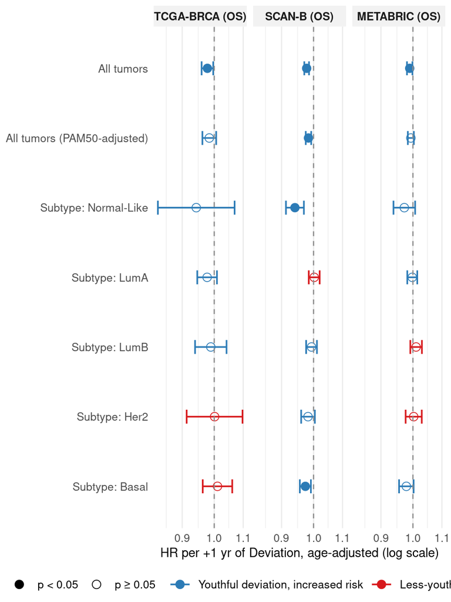

```r
panelE_df <- panelE_tbl %>%
  dplyr::mutate(
    label  = model,
    cohort = factor(cohort, levels = c("TCGA-BRCA (OS)", "SCAN-B (OS)", "METABRIC (OS)")),
    hr_dir = factor(hr_dir,
                    levels = c("Youthful deviation, increased risk",
                               "Less-youthful deviation, increased risk"))
  ) %>%
  dplyr::group_by(cohort) %>%
  dplyr::mutate(label = factor(label, levels = rev(unique(label)))) %>%
  dplyr::ungroup()

hr_pal <- c(
  "Youthful deviation, increased risk"      = "#2c7bb6",  # blue
  "Less-youthful deviation, increased risk" = "#d7191c"   # red
)

p_panelE <- ggplot(panelE_df, aes(x = HR, y = label, colour = hr_dir)) +
  geom_errorbarh(aes(xmin = CI_low, xmax = CI_high), height = 0.2, linewidth = 0.55) +
  geom_point(aes(shape = sig), size = 2.6) +
  geom_vline(xintercept = 1, linetype = "dashed", colour = "grey55") +
  scale_x_log10() +
  scale_shape_manual(values = c("p < 0.05" = 19, "p ≥ 0.05" = 1), name = NULL) +
  scale_colour_manual(values = hr_pal, name = NULL) +
  facet_wrap(~ cohort, scales = "fixed", nrow = 1) +
  labs(
    x = "HR per +1 yr of Deviation, age-adjusted (log scale)",
    y = NULL
  ) +
  theme_minimal(base_size = 9) +
  theme(
    strip.text         = element_text(face = "bold", size = 8),
    strip.background   = element_rect(fill = "grey95", colour = NA),
    panel.grid.major.y = element_blank(),
    legend.position    = "bottom",
    legend.box         = "horizontal",
    legend.spacing.y   = unit(1, "pt"),
    legend.margin      = margin(0, 0, 0, 0),
    legend.text        = element_text(size = 8),
    axis.text          = element_text(size = 8),
    axis.title         = element_text(size = 9),
    plot.margin        = margin(4, 4, 4, 4)
  )

p_panelE
```

```r
ggsave(
  filename = file.path(fig_out_dir, "OS_forest_3cohorts.pdf"),
  plot     = p_panelE,
  width    = 7.5, height = 2.5, units = "in"
)
```

## 11.4 — KM by deviation tertile, 3 cohorts stacked (not used in the manuscript)

Within-cohort deviation tertiles. T1 = most youthful, T3 = least youthful. Truncated at SCAN-B’s natural max follow-up; log-rank also administratively censored at that horizon so plot and test cover the same patient-time window. Save dimensions: 3 × 6.75 in.

```r
add_dev_tertile <- function(df) {
  qs <- stats::quantile(df$Deviation, probs = c(0, 1/3, 2/3, 1), na.rm = TRUE)
  df$dev_tertile <- cut(
    df$Deviation, breaks = qs,
    labels = c("T1: Most youthful", "T2: Middle", "T3: Least youthful"),
    include.lowest = TRUE
  )
  df
}

km_data <- dplyr::bind_rows(
  add_dev_tertile(surv_brca)  %>% dplyr::mutate(cohort = "TCGA-BRCA (OS)"),
  add_dev_tertile(surv_scanb) %>% dplyr::mutate(cohort = "SCAN-B (OS)"),
  add_dev_tertile(surv_metab) %>% dplyr::mutate(cohort = "METABRIC (OS)")
) %>%
  dplyr::mutate(
    cohort      = factor(cohort, levels = c("TCGA-BRCA (OS)", "SCAN-B (OS)", "METABRIC (OS)")),
    dev_tertile = factor(dev_tertile,
                         levels = c("T1: Most youthful", "T2: Middle", "T3: Least youthful"))
  )

# Truncation horizon = SCAN-B's natural max follow-up (the limiting cohort).
x_max <- km_data %>%
  dplyr::filter(cohort == "SCAN-B (OS)") %>%
  dplyr::pull(time) %>%
  max(na.rm = TRUE) / 365.25

trunc_data <- function(d, t_max_years) {
  t_max_days <- t_max_years * 365.25
  d %>% dplyr::mutate(
    event = event & time <= t_max_days,
    time  = pmin(time, t_max_days)
  )
}

km_data_view <- trunc_data(km_data, x_max)

km_curves <- km_data_view %>%
  dplyr::group_by(cohort, dev_tertile) %>%
  dplyr::group_modify(function(d, .) {
    if (nrow(d) < 5 || sum(d$event) < 1) return(tibble::tibble())
    fit <- survival::survfit(survival::Surv(time, event) ~ 1, data = d)
    tibble::tibble(time = fit$time, surv = fit$surv,
                   n_risk = fit$n.risk, n_event = fit$n.event)
  }) %>%
  dplyr::ungroup()

# Per-cohort log-rank on truncated data
lr_brca  <- survival::survdiff(
  survival::Surv(time, event) ~ dev_tertile,
  data = dplyr::filter(km_data_view, cohort == "TCGA-BRCA (OS)")
)
lr_scanb <- survival::survdiff(
  survival::Surv(time, event) ~ dev_tertile,
  data = dplyr::filter(km_data_view, cohort == "SCAN-B (OS)")
)
lr_metab <- survival::survdiff(
  survival::Surv(time, event) ~ dev_tertile,
  data = dplyr::filter(km_data_view, cohort == "METABRIC (OS)")
)

lr_p <- function(sd) 1 - stats::pchisq(sd$chisq, length(sd$n) - 1)

logrank_tbl <- tibble::tibble(
  cohort         = c("TCGA-BRCA (OS)", "SCAN-B (OS)", "METABRIC (OS)"),
  log_rank_chisq = c(lr_brca$chisq, lr_scanb$chisq, lr_metab$chisq),
  p_value        = c(lr_p(lr_brca), lr_p(lr_scanb), lr_p(lr_metab))
)
knitr::kable(
  logrank_tbl, digits = 4,
  caption = sprintf(
    "Unadjusted log-rank test by deviation tertile, per cohort (administratively censored at %.2f years to match SCAN-B follow-up).",
    x_max
  )
)
```

Unadjusted log-rank test by deviation tertile, per cohort (administratively censored at 11.87 years to match SCAN-B follow-up).

| cohort | log_rank_chisq | p_value |
| --- | --- | --- |
| TCGA-BRCA (OS) | 11.2431 | 0.0036 |
| SCAN-B (OS) | 158.2149 | 0.0000 |
| METABRIC (OS) | 33.7926 | 0.0000 |

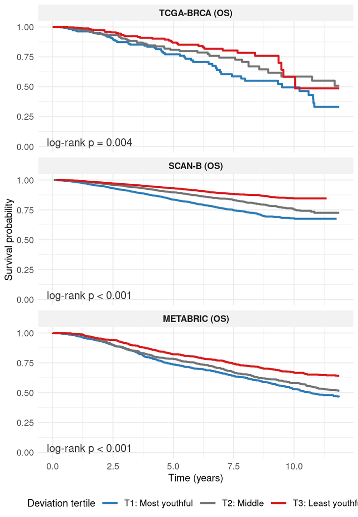

```r
logrank_labels <- logrank_tbl %>%
  dplyr::mutate(
    cohort  = factor(cohort, levels = c("TCGA-BRCA (OS)", "SCAN-B (OS)", "METABRIC (OS)")),
    p_label = dplyr::case_when(
      p_value < 0.001 ~ "log-rank p < 0.001",
      TRUE            ~ sprintf("log-rank p = %.3f", p_value)
    )
  )

p_panelF <- ggplot(km_curves, aes(x = time / 365.25, y = surv, colour = dev_tertile)) +
  geom_step(linewidth = 0.85) +
  scale_colour_manual(
    values = c("T1: Most youthful"  = "#2c7bb6",
               "T2: Middle"         = "grey45",
               "T3: Least youthful" = "#d7191c"),
    name = "Deviation tertile"
  ) +
  facet_wrap(~ cohort, ncol = 1) +
  geom_text(
    data        = logrank_labels,
    aes(label = p_label),
    x = -Inf, y = -Inf, hjust = -0.1, vjust = -0.8,
    inherit.aes = FALSE, size = 3.4, colour = "grey20"
  ) +
  coord_cartesian(xlim = c(0, x_max), ylim = c(0, 1)) +
  labs(
    x = "Time (years)",
    y = "Survival probability"
  ) +
  theme_minimal(base_size = 9) +
  theme(
    strip.text         = element_text(face = "bold", size = 8),
    strip.background   = element_rect(fill = "grey95", colour = NA),
    legend.position    = "bottom",
    legend.text        = element_text(size = 8),
    legend.title       = element_text(size = 9),
    legend.spacing.y   = unit(1, "pt"),
    legend.margin      = margin(0, 0, 0, 0),
    axis.text          = element_text(size = 8),
    axis.title         = element_text(size = 9),
    plot.margin        = margin(4, 4, 4, 4)
  )

p_panelF
```

```r
ggsave(
  filename = file.path(fig_out_dir, "OS_KM_tertile_3cohorts.pdf"),
  plot     = p_panelF,
  width    = 3, height = 6.75, units = "in"
)
```

# 12. Stability diagnostics

## 12.1 Hallmark coverage in the common universe

```r
hallmark_sizes <- tibble(
  pathway = names(hallmark_sets),
  n_total = vapply(hallmark_sets, length, integer(1))
)

count_present <- function(universe) {
  vapply(hallmark_sets, function(g) sum(g %in% universe), integer(1))
}

retained_pathways <- names(b_orig)[b_orig != 0]
top_contrib       <- names(sort(abs(b_orig), decreasing = TRUE))[1:10]

coverage_tbl <- hallmark_sizes %>%
  mutate(
    n_gtex     = count_present(rownames(logcpm_gtex_sym)),
    n_tcga_pt  = count_present(rownames(logcpm_pt_sym)),
    n_scanb    = count_present(rownames(logcpm_scanb_sym)),
    n_metab    = count_present(rownames(logcpm_metab_sym)),
    n_common   = count_present(universe_common),
    pct_common = round(100 * n_common / n_total, 1),
    retained_in_clock = pathway %in% retained_pathways,
    top10_contrib     = pathway %in% top_contrib
  ) %>%
  arrange(pct_common)

cat("Coverage in common universe:\n")
```

```
## Coverage in common universe:
```

```r
cat("  Median %:    ", round(median(coverage_tbl$pct_common), 1), "\n")
```

```
##   Median %:     92
```

```r
cat("  Min %:       ", round(min(coverage_tbl$pct_common), 1),
    " (", coverage_tbl$pathway[which.min(coverage_tbl$pct_common)], ")\n", sep = "")
```

```
##   Min %:       84.6 (Oxidative Phosphorylation)
```

```r
cat("  # < 60%:     ", sum(coverage_tbl$pct_common < 60), " of 50\n")
```

```
##   # < 60%:      0  of 50
```

```r
cat("  # < 80%:     ", sum(coverage_tbl$pct_common < 80), " of 50\n")
```

```
##   # < 80%:      0  of 50
```

```r
cat("\nClock-retained pathways — coverage in common universe:\n")
```

```
##
## Clock-retained pathways — coverage in common universe:
```

```r
cat("  Median %:    ", round(median(coverage_tbl$pct_common[coverage_tbl$retained_in_clock]), 1), "\n")
```

```
##   Median %:     92.8
```

```r
cat("  Min %:       ", round(min(coverage_tbl$pct_common[coverage_tbl$retained_in_clock]), 1), "\n")
```

```
##   Min %:        85.7
```

```r
print(coverage_tbl)
```

```
## # A tibble: 50 × 10
##    pathway          n_total n_gtex n_tcga_pt n_scanb n_metab n_common pct_common
##    <chr>              <int>  <int>     <int>   <int>   <int>    <int>      <dbl>
##  1 Oxidative Phosp…     201    186       186     201     170      170       84.6
##  2 Reactive Oxygen…      49     49        49      48      43       42       85.7
##  3 Dna Repair           150    148       148     150     130      130       86.7
##  4 Interferon Alph…      97     95        95      97      85       85       87.6
##  5 Adipogenesis         200    194       194     200     176      176       88
##  6 Androgen Respon…     101     98        98     100      90       89       88.1
##  7 Unfolded Protei…     113    108       108     113     100      100       88.5
##  8 Allograft Rejec…     200    195       195     200     178      178       89
##  9 Estrogen Respon…     200    195       195     200     178      178       89
## 10 Kras Signaling …     200    197       197     200     178      178       89
## # ℹ 40 more rows
## # ℹ 2 more variables: retained_in_clock <lgl>, top10_contrib <lgl>
```

## 12.2 Original (full universe) vs retrained (common universe) clock comparison

```r
orig_clock_path <- file.path(proc_dir, "clock_and_RAA_objects-PC.rds")
stopifnot(file.exists(orig_clock_path))
orig_clock <- readRDS(orig_clock_path)

required_slots <- c("feature_names", "tuning", "enet_model", "clock_raw")
stopifnot(length(setdiff(required_slots, names(orig_clock))) == 0)

orig_alpha  <- orig_clock$tuning$best_alpha
orig_lambda <- orig_clock$tuning$best_lambda
orig_b      <- orig_clock$clock_raw$beta
orig_a      <- orig_clock$clock_raw$alpha
orig_feats  <- orig_clock$feature_names

orig_metric_col <- if (orig_clock$tuning$lambda_choice == "lambda.min") "MAE.min" else "MAE.1se"
orig_mae <- orig_clock$tuning$tune_table %>%
  dplyr::filter(abs(alpha - orig_alpha) < 1e-9) %>%
  dplyr::pull(.data[[orig_metric_col]])

new_alpha  <- best_alpha
new_lambda <- best_lambda
new_b      <- b_orig
new_a      <- a_orig
new_mae    <- best_mae
new_feats  <- feat

# Hyperparameter table
hp_tbl <- tibble(
  metric = c("alpha", "lambda", "intercept",
             paste0("CV MAE (", orig_clock$tuning$lambda_choice, ")"),
             "n features (Hallmarks)",
             "n retained (nonzero)"),
  original  = c(signif(orig_alpha, 3),  signif(orig_lambda, 4),  signif(orig_a, 4),
                signif(orig_mae, 4),    length(orig_feats),       sum(orig_b != 0)),
  retrained = c(signif(new_alpha, 3),   signif(new_lambda, 4),   signif(new_a, 4),
                signif(new_mae, 4),     length(new_feats),        sum(new_b != 0))
)
cat("Hyperparameter & training-fit comparison:\n")
```

```
## Hyperparameter & training-fit comparison:
```

```r
print(hp_tbl)
```

```
## # A tibble: 6 × 3
##   metric                 original retrained
##   <chr>                     <dbl>     <dbl>
## 1 alpha                     0.6        0.2
## 2 lambda                    0.579      2.36
## 3 intercept                -9.04       8.68
## 4 CV MAE (lambda.1se)       9.74       9.82
## 5 n features (Hallmarks)   50         50
## 6 n retained (nonzero)     18         16
```

```r
# Coefficient agreement
all_paths <- union(orig_feats, new_feats)
comp <- tibble(
  pathway   = all_paths,
  orig_coef = as.numeric(orig_b[all_paths]),
  new_coef  = as.numeric(new_b[all_paths])
) %>%
  mutate(
    orig_coef = ifelse(is.na(orig_coef), 0, orig_coef),
    new_coef  = ifelse(is.na(new_coef),  0, new_coef),
    in_orig   = orig_coef != 0,
    in_new    = new_coef  != 0,
    sign_agree = sign(orig_coef) == sign(new_coef)
  )

both_retained   <- sum(comp$in_orig & comp$in_new)
either_retained <- sum(comp$in_orig | comp$in_new)
jaccard_retained <- both_retained / either_retained

cat("\nPathway-set agreement:\n")
```

```
##
## Pathway-set agreement:
```

```r
cat("  Retained in both:           ", both_retained, "\n")
```

```
##   Retained in both:            15
```

```r
cat("  Retained in original only:  ", sum(comp$in_orig & !comp$in_new), "\n")
```

```
##   Retained in original only:   3
```

```r
cat("  Retained in retrained only: ", sum(!comp$in_orig & comp$in_new), "\n")
```

```
##   Retained in retrained only:  1
```

```r
cat("  Jaccard (retained set):     ", round(jaccard_retained, 3), "\n")
```

```
##   Jaccard (retained set):      0.789
```

```r
shared <- comp %>% filter(in_orig & in_new)
spearman_shared <- cor(shared$orig_coef, shared$new_coef, method = "spearman")
sign_concord_shared <- mean(shared$sign_agree)

cat("\nCoefficient agreement on shared retained pathways (n=", nrow(shared), "):\n", sep = "")
```

```
##
## Coefficient agreement on shared retained pathways (n=15):
```

```r
cat("  Spearman:                   ", round(spearman_shared, 3), "\n")
```

```
##   Spearman:                    0.721
```

```r
cat("  Sign concordance:           ", round(sign_concord_shared, 3), "\n")
```

```
##   Sign concordance:            1
```

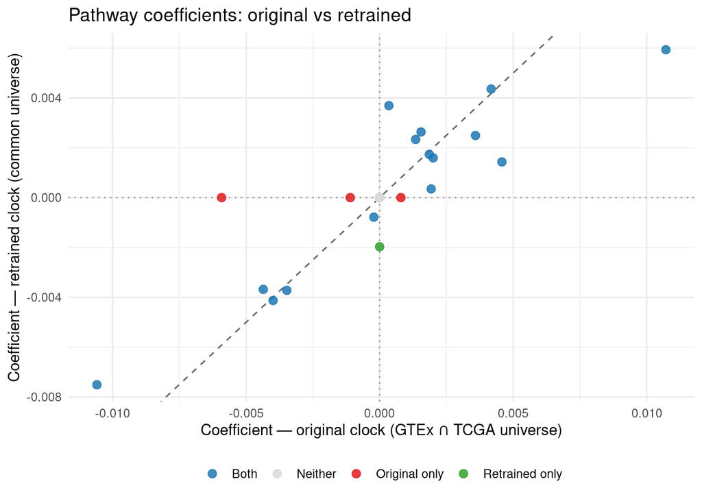

```r
# Coefficient scatter
ggplot(comp, aes(orig_coef, new_coef)) +
  geom_hline(yintercept = 0, linetype = "dotted", color = "grey60") +
  geom_vline(xintercept = 0, linetype = "dotted", color = "grey60") +
  geom_abline(slope = 1, intercept = 0, linetype = "dashed", color = "grey40") +
  geom_point(aes(color = case_when(
    in_orig &  in_new ~ "Both",
    in_orig & !in_new ~ "Original only",
    !in_orig &  in_new ~ "Retrained only",
    TRUE ~ "Neither"
  )), size = 2.5, alpha = 0.85) +
  scale_color_manual(values = c(
    Both = "#1f78b4", `Original only` = "#e31a1c",
    `Retrained only` = "#33a02c", Neither = "grey85"
  ), name = NULL) +
  labs(
    x = "Coefficient — original clock (GTEx ∩ TCGA universe)",
    y = "Coefficient — retrained clock (common universe)",
    title = "Pathway coefficients: original vs retrained"
  ) +
  theme_minimal(base_size = 11) +
  theme(legend.position = "bottom")
```

## 12.3 METABRIC sample composition audit

```r
mb_cd_diag <- as.data.frame(colData(metabric_se))
cat("METABRIC colData dimensions: ", paste(dim(mb_cd_diag), collapse = " x "), "\n\n")
```

```
## METABRIC colData dimensions:  1980 x 34
```

```r
for (col in c("CANCER_TYPE_DETAILED", "HISTOLOGICAL_SUBTYPE",
              "SAMPLE_TYPE", "Pam50_SUBTYPE")) {
  if (col %in% colnames(mb_cd_diag)) {
    cat("\n--- ", col, " ---\n", sep = "")
    print(table(mb_cd_diag[[col]], useNA = "ifany"))
  }
}
```

```
##
## --- CANCER_TYPE_DETAILED ---
##
## Breast Invasive Ductal Carcinoma
##                             1980
##
## --- SAMPLE_TYPE ---
##
## Primary
##    1980
##
## --- Pam50_SUBTYPE ---
##
##  Basal   Her2   LumA   LumB     NC Normal
##    329    240    718    488      6    199
```